# Descriptive Statistics with Python

This chapter aims to learn how to perform your first data analysis using Python. We will first talk about the types of variables found in any collected dataset. We then show the kind of statistics that should be calculated: mean, median, mode, to provide a good description of the data. We finish the chapter by showing how to study the pairwise relationships between variables. We will then show how to compute correlation coefficients and draw the correlation's heat map. We will also present the $\chi^2-$test to determine the nature of the relationship between two categorical variables

Learning outcomes:

- Types of variables
- Discrete variables, frequency, proportions, percentages
- Measuring central tendency for continuous variables: Mean, Median, Quantiles
- Measuring dispersion for continuous variables: Range, IQR, Variance, STD
- Relationship between two continuous variables: Correlation coefficient and matrix, heat map.
- Relationship between two discrete variables: Independence models, $\chi^2-$test, mosaic plot.

# Table of Contents

## Type of variables

### Discrete Variable

```python
import pandas as pd
```

```python
df=pd.read_csv("data1.csv",index_col='EmployeeNumber')
```

```python
df
```

| EmployeeNumber | Age | Attrition | BusinessTravel | DailyRate | Department | DistanceFromHome | Education | EducationField | EmployeeCount | EnvironmentSatisfaction | ... | RelationshipSatisfaction | StandardHours | StockOptionLevel | TotalWorkingYears | TrainingTimesLastYear | WorkLifeBalance | YearsAtCompany | YearsInCurrentRole | YearsSinceLastPromotion | YearsWithCurrManager |
| --- | --- | --- | --- | --- | --- | --- | --- | --- | --- | --- | --- | --- | --- | --- | --- | --- | --- | --- | --- | --- | --- |
| 1 | 41 | Yes | Travel_Rarely | 1102 | Sales | 1 | 2 | Life Sciences | 1 | 2 | ... | 1 | 80 | 0 | 8 | 0 | 1 | 6 | 4 | 0 | 5 |
| 2 | 49 | No | Travel_Frequently | 279 | Research & Development | 8 | 1 | Life Sciences | 1 | 3 | ... | 4 | 80 | 1 | 10 | 3 | 3 | 10 | 7 | 1 | 7 |
| 4 | 37 | Yes | Travel_Rarely | 1373 | Research & Development | 2 | 2 | Other | 1 | 4 | ... | 2 | 80 | 0 | 7 | 3 | 3 | 0 | 0 | 0 | 0 |
| 5 | 33 | No | Travel_Frequently | 1392 | Research & Development | 3 | 4 | Life Sciences | 1 | 4 | ... | 3 | 80 | 0 | 8 | 3 | 3 | 8 | 7 | 3 | 0 |
| 7 | 27 | No | Travel_Rarely | 591 | Research & Development | 2 | 1 | Medical | 1 | 1 | ... | 4 | 80 | 1 | 6 | 3 | 3 | 2 | 2 | 2 | 2 |
| ... | ... | ... | ... | ... | ... | ... | ... | ... | ... | ... | ... | ... | ... | ... | ... | ... | ... | ... | ... | ... | ... |
| 2061 | 36 | No | Travel_Frequently | 884 | Research & Development | 23 | 2 | Medical | 1 | 3 | ... | 3 | 80 | 1 | 17 | 3 | 3 | 5 | 2 | 0 | 3 |
| 2062 | 39 | No | Travel_Rarely | 613 | Research & Development | 6 | 1 | Medical | 1 | 4 | ... | 1 | 80 | 1 | 9 | 5 | 3 | 7 | 7 | 1 | 7 |
| 2064 | 27 | No | Travel_Rarely | 155 | Research & Development | 4 | 3 | Life Sciences | 1 | 2 | ... | 2 | 80 | 1 | 6 | 0 | 3 | 6 | 2 | 0 | 3 |
| 2065 | 49 | No | Travel_Frequently | 1023 | Sales | 2 | 3 | Medical | 1 | 4 | ... | 4 | 80 | 0 | 17 | 3 | 2 | 9 | 6 | 0 | 8 |
| 2068 | 34 | No | Travel_Rarely | 628 | Research & Development | 8 | 3 | Medical | 1 | 2 | ... | 1 | 80 | 0 | 6 | 3 | 4 | 4 | 3 | 1 | 2 |

1470 rows × 34 columns

```python
df.columns
```

```
Index(['Age', 'Attrition', 'BusinessTravel', 'DailyRate', 'Department',
       'DistanceFromHome', 'Education', 'EducationField', 'EmployeeCount',
       'EnvironmentSatisfaction', 'Gender', 'HourlyRate', 'JobInvolvement',
       'JobLevel', 'JobRole', 'JobSatisfaction', 'MaritalStatus',
       'MonthlyIncome', 'MonthlyRate', 'NumCompaniesWorked', 'Over18',
       'OverTime', 'PercentSalaryHike', 'PerformanceRating',
       'RelationshipSatisfaction', 'StandardHours', 'StockOptionLevel',
       'TotalWorkingYears', 'TrainingTimesLastYear', 'WorkLifeBalance',
       'YearsAtCompany', 'YearsInCurrentRole', 'YearsSinceLastPromotion',
       'YearsWithCurrManager'],
      dtype='object')
```

```python
df['JobSatisfaction']
```

```
EmployeeNumber
1       4
2       2
4       3
5       3
7       2
       ..
2061    4
2062    1
2064    2
2065    2
2068    3
Name: JobSatisfaction, Length: 1470, dtype: int64
```

```python
df['Attrition'].value_counts()
```

```
No     1233
Yes     237
Name: Attrition, dtype: int64
```

```python
df['Gender'].value_counts()
```

```
Male      882
Female    588
Name: Gender, dtype: int64
```

```python
df['JobSatisfaction'].value_counts()
```

```
4    459
3    442
1    289
2    280
Name: JobSatisfaction, dtype: int64
```

```python
df['Age'].value_counts()
```

```
35    78
34    77
36    69
31    69
29    68
32    61
30    60
33    58
38    58
40    57
37    50
27    48
28    48
42    46
39    42
```

[output cut: 29 more lines]

```python
df['Attrition'].value_counts()
```

```
No     1233
Yes     237
Name: Attrition, dtype: int64
```

```python
df['Attrition'].value_counts(normalize=True)
```

```
No     0.838776
Yes    0.161224
Name: Attrition, dtype: float64
```

### Continuous Variable

#### Measuring central tendancy

**Mean**: $\overline{x}=\displaystyle\frac{1}{n}\displaystyle\sum_{i=1}^n x_i$

```python
df['Age'].mean()
```

```
36.923809523809524
```

```python
df['Education'].value_counts()
```

```
3    572
4    398
2    282
1    170
5     48
Name: Education, dtype: int64
```

```python
df['Education'].mean()
```

```
2.912925170068027
```

The **mode** is the highest-occuring item in a group of observations

```python
df['Age'].mode()
```

```
0    35
dtype: int64
```

```python
df['Age'][0:10]
```

```
EmployeeNumber
1     41
2     49
4     37
5     33
7     27
8     32
10    59
11    30
12    38
13    36
Name: Age, dtype: int64
```

```python
df['Age'][0:10].mode()
```

```
0    27
1    30
2    32
3    33
4    36
5    37
6    38
7    41
8    49
9    59
dtype: int64
```

The **median** is the midpoint or middle value in a group of observations. It is also called the 50th percentile.

```python
df['Age'].median()
```

```
36.0
```

The **median** is also called the **50% quantile** or the **2nd quantile**

```python
df['Age'].quantile(.5)
```

```
36.0
```

we can compute the **1st quantile** or the **25% quantile**

```python
df['Age'].quantile(.25)
```

```
30.0
```

and the the **3rd quantile** or the **75% quantile**

```python
df['Age'].quantile(.75)
```

```
43.0
```

```python
df['Age'].quantile(.1)
```

```
26.0
```

```python
df['Age'].quantile(.2)
```

```
29.0
```

And we can compute **the five numbers summary**. It's composed of the `min`, `1st quantile`, `median`, `3rd quantile`, and `max`

```python
df['Age'].quantile([0,.25,.5,.75,1])
```

```
0.00    18.0
0.25    30.0
0.50    36.0
0.75    43.0
1.00    60.0
Name: Age, dtype: float64
```

#### Measuring dispersion

**Range** is the difference between the maximum and the minimum

```python
df['Age'].max()
```

```
60
```

```python
df['Age'].min()
```

```
18
```

```python
df['Age'].max()-df['Age'].min()
```

```
42
```

The **Inter-quantile range**:

```python
df['Age'].quantile(.75)-df['Age'].quantile(.25)
```

```
13.0
```

The **Variance** measures the deviation from the mean $$\sigma^2=\displaystyle\frac{1}{n-1}\sum_{i=1}^n (x_i-\overline{x})^2$$

```python
df['Age'].var()
```

```
83.45504878602227
```

```python
xbar=df['Age'].mean()
```

```python
y=(df['Age']-xbar)**2
```

```python
4**2
```

```
16
```

```python
y[0:4]
```

```
EmployeeNumber
1     16.615329
2    145.834376
4      0.005805
5     15.396281
Name: Age, dtype: float64
```

```python
n=len(df['Age'])
```

```python
n
```

```
1470
```

```python
sum(y)
```

```
122595.46666666672
```

```python
sum(y)/n
```

```
83.39827664399097
```

```python
sum(y)/(n-1)
```

```
83.45504878602227
```

The **standard deviation** is the square root of the variance

```python
df['Age'].std()
```

```
9.135373489136734
```

```python
df['Age'].var()**(.5)
```

```
9.135373489136734
```

We can also compute all these measures using one `Python` function

```python
df['Age'].describe()
```

```
count    1470.000000
mean       36.923810
std         9.135373
min        18.000000
25%        30.000000
50%        36.000000
75%        43.000000
max        60.000000
Name: Age, dtype: float64
```

`describe` can be used on the whole dataset.

```python
df.describe()
```

|  | Age | DailyRate | DistanceFromHome | Education | EmployeeCount | EnvironmentSatisfaction | HourlyRate | JobInvolvement | JobLevel | JobSatisfaction | ... | RelationshipSatisfaction | StandardHours | StockOptionLevel | TotalWorkingYears | TrainingTimesLastYear | WorkLifeBalance | YearsAtCompany | YearsInCurrentRole | YearsSinceLastPromotion | YearsWithCurrManager |
| --- | --- | --- | --- | --- | --- | --- | --- | --- | --- | --- | --- | --- | --- | --- | --- | --- | --- | --- | --- | --- | --- |
| count | 1470.000000 | 1470.000000 | 1470.000000 | 1470.000000 | 1470.0 | 1470.000000 | 1470.000000 | 1470.000000 | 1470.000000 | 1470.000000 | ... | 1470.000000 | 1470.0 | 1470.000000 | 1470.000000 | 1470.000000 | 1470.000000 | 1470.000000 | 1470.000000 | 1470.000000 | 1470.000000 |
| mean | 36.923810 | 802.485714 | 9.192517 | 2.912925 | 1.0 | 2.721769 | 65.891156 | 2.729932 | 2.063946 | 2.728571 | ... | 2.712245 | 80.0 | 0.793878 | 11.279592 | 2.799320 | 2.761224 | 7.008163 | 4.229252 | 2.187755 | 4.123129 |
| std | 9.135373 | 403.509100 | 8.106864 | 1.024165 | 0.0 | 1.093082 | 20.329428 | 0.711561 | 1.106940 | 1.102846 | ... | 1.081209 | 0.0 | 0.852077 | 7.780782 | 1.289271 | 0.706476 | 6.126525 | 3.623137 | 3.222430 | 3.568136 |
| min | 18.000000 | 102.000000 | 1.000000 | 1.000000 | 1.0 | 1.000000 | 30.000000 | 1.000000 | 1.000000 | 1.000000 | ... | 1.000000 | 80.0 | 0.000000 | 0.000000 | 0.000000 | 1.000000 | 0.000000 | 0.000000 | 0.000000 | 0.000000 |
| 25% | 30.000000 | 465.000000 | 2.000000 | 2.000000 | 1.0 | 2.000000 | 48.000000 | 2.000000 | 1.000000 | 2.000000 | ... | 2.000000 | 80.0 | 0.000000 | 6.000000 | 2.000000 | 2.000000 | 3.000000 | 2.000000 | 0.000000 | 2.000000 |
| 50% | 36.000000 | 802.000000 | 7.000000 | 3.000000 | 1.0 | 3.000000 | 66.000000 | 3.000000 | 2.000000 | 3.000000 | ... | 3.000000 | 80.0 | 1.000000 | 10.000000 | 3.000000 | 3.000000 | 5.000000 | 3.000000 | 1.000000 | 3.000000 |
| 75% | 43.000000 | 1157.000000 | 14.000000 | 4.000000 | 1.0 | 4.000000 | 83.750000 | 3.000000 | 3.000000 | 4.000000 | ... | 4.000000 | 80.0 | 1.000000 | 15.000000 | 3.000000 | 3.000000 | 9.000000 | 7.000000 | 3.000000 | 7.000000 |
| max | 60.000000 | 1499.000000 | 29.000000 | 5.000000 | 1.0 | 4.000000 | 100.000000 | 4.000000 | 5.000000 | 4.000000 | ... | 4.000000 | 80.0 | 3.000000 | 40.000000 | 6.000000 | 4.000000 | 40.000000 | 18.000000 | 15.000000 | 17.000000 |

8 rows × 25 columns

## Measure relationship between two variables

In statistics, we're always to find the variables that are related to each other. After the one-dimensional description of the variables (called also `flat sorting` of the data) we explore also the pairwise relationship between the variables.

### Between two continuous variables

- If $\rho$ is close to zero, we conclude that there's no evidence of a linear relationship between the two variables
- If $\rho$ is close to +1, there's probably a *positive* relationship between the two variables
- If $\rho$ is close to -1, there's probably a *negative* relationship between the two variables

Before computing $\rho$ we should first draw a plot call the **scatter plot**:

```python
df.columns
```

```
Index(['Age', 'Attrition', 'BusinessTravel', 'DailyRate', 'Department',
       'DistanceFromHome', 'Education', 'EducationField', 'EmployeeCount',
       'EnvironmentSatisfaction', 'Gender', 'HourlyRate', 'JobInvolvement',
       'JobLevel', 'JobRole', 'JobSatisfaction', 'MaritalStatus',
       'MonthlyIncome', 'MonthlyRate', 'NumCompaniesWorked', 'Over18',
       'OverTime', 'PercentSalaryHike', 'PerformanceRating',
       'RelationshipSatisfaction', 'StandardHours', 'StockOptionLevel',
       'TotalWorkingYears', 'TrainingTimesLastYear', 'WorkLifeBalance',
       'YearsAtCompany', 'YearsInCurrentRole', 'YearsSinceLastPromotion',
       'YearsWithCurrManager'],
      dtype='object')
```

We will check the relationship between `HourlyRate` and `YearsAtCompany`. We will first draw the scatter plot. We need then to install `matplotlib` library.

```python
!pip install matplotlib
```

We import then `matplotlib`

```python
import matplotlib.pyplot as plt
```

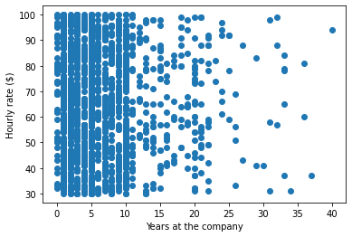

```python
plt.scatter(df['YearsAtCompany'],df['HourlyRate'])
plt.ylabel("Hourly rate ($)")
plt.xlabel("Years at the company")
plt.show()
```

The correlation coefficient between these two variables is displayed in the following matrix

```python
df[['YearsAtCompany','HourlyRate']].corr(method='pearson')
```

|  | YearsAtCompany | HourlyRate |
| --- | --- | --- |
| YearsAtCompany | 1.000000 | -0.019582 |
| HourlyRate | -0.019582 | 1.000000 |

and $\rho$ can be extracted as follows

```python
x=df[['YearsAtCompany','HourlyRate']].corr(method='pearson')
```

```python
import numpy as np
```

```python
x=np.array(x)
```

```python
x[0,1]
```

```
-0.01958161620912128
```

**Interpreation**: there's no evidence of a linear relationship between the variables HourlyRate and YearsAtCompany

We can also compute at the same all the pairwise correlations between the variables of the data. **ONLY CORRELATIONS BETWEEN CONTINUOUS VARIABLES HAVE A STATISTICAL INTERPRETATION**.

```python
df.corr()
```

|  | Age | DailyRate | DistanceFromHome | Education | EmployeeCount | EnvironmentSatisfaction | HourlyRate | JobInvolvement | JobLevel | JobSatisfaction | ... | RelationshipSatisfaction | StandardHours | StockOptionLevel | TotalWorkingYears | TrainingTimesLastYear | WorkLifeBalance | YearsAtCompany | YearsInCurrentRole | YearsSinceLastPromotion | YearsWithCurrManager |
| --- | --- | --- | --- | --- | --- | --- | --- | --- | --- | --- | --- | --- | --- | --- | --- | --- | --- | --- | --- | --- | --- |
| Age | 1.000000 | 0.010661 | -0.001686 | 0.208034 | NaN | 0.010146 | 0.024287 | 0.029820 | 0.509604 | -0.004892 | ... | 0.053535 | NaN | 0.037510 | 0.680381 | -0.019621 | -0.021490 | 0.311309 | 0.212901 | 0.216513 | 0.202089 |
| DailyRate | 0.010661 | 1.000000 | -0.004985 | -0.016806 | NaN | 0.018355 | 0.023381 | 0.046135 | 0.002966 | 0.030571 | ... | 0.007846 | NaN | 0.042143 | 0.014515 | 0.002453 | -0.037848 | -0.034055 | 0.009932 | -0.033229 | -0.026363 |
| DistanceFromHome | -0.001686 | -0.004985 | 1.000000 | 0.021042 | NaN | -0.016075 | 0.031131 | 0.008783 | 0.005303 | -0.003669 | ... | 0.006557 | NaN | 0.044872 | 0.004628 | -0.036942 | -0.026556 | 0.009508 | 0.018845 | 0.010029 | 0.014406 |
| Education | 0.208034 | -0.016806 | 0.021042 | 1.000000 | NaN | -0.027128 | 0.016775 | 0.042438 | 0.101589 | -0.011296 | ... | -0.009118 | NaN | 0.018422 | 0.148280 | -0.025100 | 0.009819 | 0.069114 | 0.060236 | 0.054254 | 0.069065 |
| EmployeeCount | NaN | NaN | NaN | NaN | NaN | NaN | NaN | NaN | NaN | NaN | ... | NaN | NaN | NaN | NaN | NaN | NaN | NaN | NaN | NaN | NaN |
| EnvironmentSatisfaction | 0.010146 | 0.018355 | -0.016075 | -0.027128 | NaN | 1.000000 | -0.049857 | -0.008278 | 0.001212 | -0.006784 | ... | 0.007665 | NaN | 0.003432 | -0.002693 | -0.019359 | 0.027627 | 0.001458 | 0.018007 | 0.016194 | -0.004999 |
| HourlyRate | 0.024287 | 0.023381 | 0.031131 | 0.016775 | NaN | -0.049857 | 1.000000 | 0.042861 | -0.027853 | -0.071335 | ... | 0.001330 | NaN | 0.050263 | -0.002334 | -0.008548 | -0.004607 | -0.019582 | -0.024106 | -0.026716 | -0.020123 |
| JobInvolvement | 0.029820 | 0.046135 | 0.008783 | 0.042438 | NaN | -0.008278 | 0.042861 | 1.000000 | -0.012630 | -0.021476 | ... | 0.034297 | NaN | 0.021523 | -0.005533 | -0.015338 | -0.014617 | -0.021355 | 0.008717 | -0.024184 | 0.025976 |
| JobLevel | 0.509604 | 0.002966 | 0.005303 | 0.101589 | NaN | 0.001212 | -0.027853 | -0.012630 | 1.000000 | -0.001944 | ... | 0.021642 | NaN | 0.013984 | 0.782208 | -0.018191 | 0.037818 | 0.534739 | 0.389447 | 0.353885 | 0.375281 |
| JobSatisfaction | -0.004892 | 0.030571 | -0.003669 | -0.011296 | NaN | -0.006784 | -0.071335 | -0.021476 | -0.001944 | 1.000000 | ... | -0.012454 | NaN | 0.010690 | -0.020185 | -0.005779 | -0.019459 | -0.003803 | -0.002305 | -0.018214 | -0.027656 |
| MonthlyIncome | 0.497855 | 0.007707 | -0.017014 | 0.094961 | NaN | -0.006259 | -0.015794 | -0.015271 | 0.950300 | -0.007157 | ... | 0.025873 | NaN | 0.005408 | 0.772893 | -0.021736 | 0.030683 | 0.514285 | 0.363818 | 0.344978 | 0.344079 |
| MonthlyRate | 0.028051 | -0.032182 | 0.027473 | -0.026084 | NaN | 0.037600 | -0.015297 | -0.016322 | 0.039563 | 0.000644 | ... | -0.004085 | NaN | -0.034323 | 0.026442 | 0.001467 | 0.007963 | -0.023655 | -0.012815 | 0.001567 | -0.036746 |
| NumCompaniesWorked | 0.299635 | 0.038153 | -0.029251 | 0.126317 | NaN | 0.012594 | 0.022157 | 0.015012 | 0.142501 | -0.055699 | ... | 0.052733 | NaN | 0.030075 | 0.237639 | -0.066054 | -0.008366 | -0.118421 | -0.090754 | -0.036814 | -0.110319 |
| PercentSalaryHike | 0.003634 | 0.022704 | 0.040235 | -0.011111 | NaN | -0.031701 | -0.009062 | -0.017205 | -0.034730 | 0.020002 | ... | -0.040490 | NaN | 0.007528 | -0.020608 | -0.005221 | -0.003280 | -0.035991 | -0.001520 | -0.022154 | -0.011985 |
| PerformanceRating | 0.001904 | 0.000473 | 0.027110 | -0.024539 | NaN | -0.029548 | -0.002172 | -0.029071 | -0.021222 | 0.002297 | ... | -0.031351 | NaN | 0.003506 | 0.006744 | -0.015579 | 0.002572 | 0.003435 | 0.034986 | 0.017896 | 0.022827 |
| RelationshipSatisfaction | 0.053535 | 0.007846 | 0.006557 | -0.009118 | NaN | 0.007665 | 0.001330 | 0.034297 | 0.021642 | -0.012454 | ... | 1.000000 | NaN | -0.045952 | 0.024054 | 0.002497 | 0.019604 | 0.019367 | -0.015123 | 0.033493 | -0.000867 |
| StandardHours | NaN | NaN | NaN | NaN | NaN | NaN | NaN | NaN | NaN | NaN | ... | NaN | NaN | NaN | NaN | NaN | NaN | NaN | NaN | NaN | NaN |
| StockOptionLevel | 0.037510 | 0.042143 | 0.044872 | 0.018422 | NaN | 0.003432 | 0.050263 | 0.021523 | 0.013984 | 0.010690 | ... | -0.045952 | NaN | 1.000000 | 0.010136 | 0.011274 | 0.004129 | 0.015058 | 0.050818 | 0.014352 | 0.024698 |
| TotalWorkingYears | 0.680381 | 0.014515 | 0.004628 | 0.148280 | NaN | -0.002693 | -0.002334 | -0.005533 | 0.782208 | -0.020185 | ... | 0.024054 | NaN | 0.010136 | 1.000000 | -0.035662 | 0.001008 | 0.628133 | 0.460365 | 0.404858 | 0.459188 |
| TrainingTimesLastYear | -0.019621 | 0.002453 | -0.036942 | -0.025100 | NaN | -0.019359 | -0.008548 | -0.015338 | -0.018191 | -0.005779 | ... | 0.002497 | NaN | 0.011274 | -0.035662 | 1.000000 | 0.028072 | 0.003569 | -0.005738 | -0.002067 | -0.004096 |
| WorkLifeBalance | -0.021490 | -0.037848 | -0.026556 | 0.009819 | NaN | 0.027627 | -0.004607 | -0.014617 | 0.037818 | -0.019459 | ... | 0.019604 | NaN | 0.004129 | 0.001008 | 0.028072 | 1.000000 | 0.012089 | 0.049856 | 0.008941 | 0.002759 |
| YearsAtCompany | 0.311309 | -0.034055 | 0.009508 | 0.069114 | NaN | 0.001458 | -0.019582 | -0.021355 | 0.534739 | -0.003803 | ... | 0.019367 | NaN | 0.015058 | 0.628133 | 0.003569 | 0.012089 | 1.000000 | 0.758754 | 0.618409 | 0.769212 |
| YearsInCurrentRole | 0.212901 | 0.009932 | 0.018845 | 0.060236 | NaN | 0.018007 | -0.024106 | 0.008717 | 0.389447 | -0.002305 | ... | -0.015123 | NaN | 0.050818 | 0.460365 | -0.005738 | 0.049856 | 0.758754 | 1.000000 | 0.548056 | 0.714365 |
| YearsSinceLastPromotion | 0.216513 | -0.033229 | 0.010029 | 0.054254 | NaN | 0.016194 | -0.026716 | -0.024184 | 0.353885 | -0.018214 | ... | 0.033493 | NaN | 0.014352 | 0.404858 | -0.002067 | 0.008941 | 0.618409 | 0.548056 | 1.000000 | 0.510224 |
| YearsWithCurrManager | 0.202089 | -0.026363 | 0.014406 | 0.069065 | NaN | -0.004999 | -0.020123 | 0.025976 | 0.375281 | -0.027656 | ... | -0.000867 | NaN | 0.024698 | 0.459188 | -0.004096 | 0.002759 | 0.769212 | 0.714365 | 0.510224 | 1.000000 |

25 rows × 25 columns

**Problem**: Check the relationship between professional experience variables. We will be only interested in the following variables: `YearsAtCompany`, `YearsInCurrentRole`, `YearsSinceLastPromotion`, and `YearsWithCurrManager`

**Solution**: We will first compute the correlation matrix rounded with 2 digits

```python
cormat=df[['YearsAtCompany','YearsInCurrentRole','YearsSinceLastPromotion','YearsWithCurrManager']].corr().round(2)
cormat
```

|  | YearsAtCompany | YearsInCurrentRole | YearsSinceLastPromotion | YearsWithCurrManager |
| --- | --- | --- | --- | --- |
| YearsAtCompany | 1.00 | 0.76 | 0.62 | 0.77 |
| YearsInCurrentRole | 0.76 | 1.00 | 0.55 | 0.71 |
| YearsSinceLastPromotion | 0.62 | 0.55 | 1.00 | 0.51 |
| YearsWithCurrManager | 0.77 | 0.71 | 0.51 | 1.00 |

It's very common to represent the correlation matrix with a agraph called a **heat map**. To make this visualization we will need to install first `seaborn`

```python
!pip install seaborn
```

We import then `seaborn` library with the `matplotlib` library

```python
import seaborn as sns
import matplotlib.pyplot as plt
```

We draw then the correlation matrix `cormat` created above as a heat map

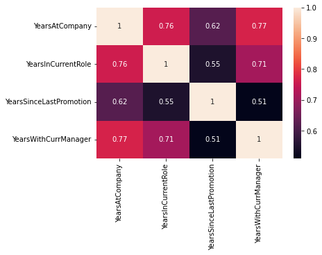

```python
sns.heatmap(cormat, annot=True)
```

### Between two disrete variables

The relationship between two discrete variables is measured using **contingency tables**.

```python
df.columns
```

```
Index(['Age', 'Attrition', 'BusinessTravel', 'DailyRate', 'Department',
       'DistanceFromHome', 'Education', 'EducationField', 'EmployeeCount',
       'EnvironmentSatisfaction', 'Gender', 'HourlyRate', 'JobInvolvement',
       'JobLevel', 'JobRole', 'JobSatisfaction', 'MaritalStatus',
       'MonthlyIncome', 'MonthlyRate', 'NumCompaniesWorked', 'Over18',
       'OverTime', 'PercentSalaryHike', 'PerformanceRating',
       'RelationshipSatisfaction', 'StandardHours', 'StockOptionLevel',
       'TotalWorkingYears', 'TrainingTimesLastYear', 'WorkLifeBalance',
       'YearsAtCompany', 'YearsInCurrentRole', 'YearsSinceLastPromotion',
       'YearsWithCurrManager'],
      dtype='object')
```

```python
df['Attrition'].value_counts()
```

```
No     1233
Yes     237
Name: Attrition, dtype: int64
```

```python
df['Gender'].value_counts()
```

```
Male      882
Female    588
Name: Gender, dtype: int64
```

A **contingency table** is a multi-way table that describes a data set in which each observation belongs to one category for each of several variables. For example, if there are two variables, one with $r$ levels and one with $k$ levels, then we have a contingency table. The table can be described in terms of the number of observations that fall into a given cell of the table, e.g. $T_{ij}$ is the number of observations that have level $i$ for the first variable and level $j$ for the second variable.

The contingency table of the variables `Attrition` and `Gender` can be computed using `crosstab` function from `Pandas` library

```python
pd.crosstab(df['Attrition'], df['Gender'])
```

| Gender Attrition | Female | Male |
| --- | --- | --- |
| No | 501 | 732 |
| Yes | 87 | 150 |

We can add margins to the contingency table

```python
pd.crosstab(df['Attrition'], df['Gender'],margins=True)
```

| Gender Attrition | Female | Male | All |
| --- | --- | --- | --- |
| No | 501 | 732 | 1233 |
| Yes | 87 | 150 | 237 |
| All | 588 | 882 | 1470 |

We will now explore the library `statsmodels` that supports a variety of approaches for analyzing contingency tables, including methods for assessing independence

In a probabilistic way, the lack of relationship between two discrete variables can be expressed using two independent variables:

Two random discrete random variables $A$ and $B$ are independent if for all $i$, $j$ $$\underbrace{\mathbb{P}(A=i,B=j)}_{P_{ij}}=\underbrace{\mathbb{P}(A=i)}_{P_{i+}}\times \underbrace{\mathbb{P}(B=j)}_{P_{+j}}$$

```python
!pip install statsmodels
```

```
     ---------------------------------------- 9.1/9.1 MB 30.7 MB/s eta 0:00:00
     ------------------------------------- 233.7/233.7 KB 14.9 MB/s eta 0:00:00
```

We import then the necessary libraries

```python
 import numpy as np
```

```python
import pandas as pd
```

```python
import statsmodels.api as sm
```

```python
tab = pd.crosstab(df['Attrition'], df['Gender'])
```

```python
tab
```

| Gender Attrition | Female | Male |
| --- | --- | --- |
| No | 501 | 732 |
| Yes | 87 | 150 |

```python
 tab.loc[:, ['Female'] ]
```

| Gender Attrition | Female |
| --- | --- |
| No | 501 |
| Yes | 87 |

```python
table = sm.stats.Table(tab)
```

```python
print(table)
```

```
A 2x2 contingency table with counts:
[[501. 732.]
 [ 87. 150.]]
```

```python
table.table
```

```
array([[501., 732.],
       [ 87., 150.]])
```

```python
table.fittedvalues
```

| Gender Attrition | Female | Male |
| --- | --- | --- |
| No | 493.2 | 739.8 |
| Yes | 94.8 | 142.2 |

```python
tab.loc[['No'],['Female']]
```

| Gender Attrition | Female |
| --- | --- |
| No | 501 |

Estimating marginal probabilities of the variable gender

```python
pG=df['Gender'].value_counts(normalize=True)
```

```python
pG
```

```
Male      0.6
Female    0.4
Name: Gender, dtype: float64
```

```python
pG[0]
```

```
0.6
```

```python
pG[1]
```

```
0.4
```

```python
pA=df['Attrition'].value_counts(normalize=True)
```

```python
pA
```

```
No     0.838776
Yes    0.161224
Name: Attrition, dtype: float64
```

```python
n=df.shape[0]
```

```python
n
```

```
1470
```

Computing the fitting contingency table

```python
tabhat=n*np.array([[pA[0]*pG[0],pA[0]*pG[1]],
              [pA[1]*pG[0],pA[1]*pG[1]]])
```

```python
print(tabhat)
```

```
[[739.8 493.2]
 [142.2  94.8]]
```

```python
tabhat.transpose()
```

```
array([[739.8, 142.2],
       [493.2,  94.8]])
```

```python
table.fittedvalues
```

| Gender Attrition | Female | Male |
| --- | --- | --- |
| No | 493.2 | 739.8 |
| Yes | 94.8 | 142.2 |

The coefficients in the previous table are called the **expected value**: $E_{ij}$ is the expected value for the cell in the $i^\mbox{th}$ column and $j^\mbox{th}$ row. $E_{ij}$ can be computed as follows: $$E_{ij}=\displaystyle\frac{T_{i+}\times T_{+j}}{N}$$ where $T_{i+}=\sum_j T_{ij}$, $T_{+j}=\sum_i T_{ij}$, and $N$ is the sample size.

We compute then the **Pearson residuals**: $$r_{ij}=\displaystyle\frac{T_{ij}-E_{ij}}{\sqrt{E_{ij}}}$$

When the variables are independents, the pearson residuals are expected to be close to zero and with a modulus non higher than 2.

```python
table.resid_pearson
```

| Gender Attrition | Female | Male |
| --- | --- | --- |
| No | 0.351223 | -0.286772 |
| Yes | -0.801107 | 0.654101 |

To decide about the relationship of the variables (independence or no), we compute the $\chi^2$ statistics and the corresponding *p-value*.

The variables `Attrition` and `Gender` are both nominal variables, we consider the test measuring the association between *nominal* variables

```python
rslt = table.test_nominal_association()
```

The $\chi^2-$statistics of the test

```python
print(rslt.statistic)
```

```
1.2752163602205142
```

It's given by $\sum_{ij}r_{ij}^2$

```python
0.35122**2+(-0.286772)**2+(-0.801107)**2+0.654101**2
```

```
1.2752142120340002
```

```python
print(rslt.df)
```

```
1
```

We consider the *p-value*

```python
print(rslt.pvalue)
```

[output not shown]

Compared to 0.05, the *p-value* is higher than 0.05, we can decide that there's no relationship between the variables `Attrition` and `Gender`.

To finish this analysis we show draw the `mosaic` plot implemented in `statsmodels` library

```python
import matplotlib.pyplot as plt
from statsmodels.graphics.mosaicplot import mosaic
```

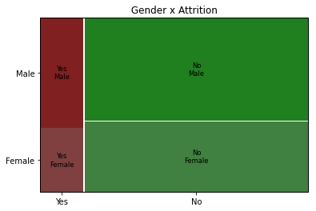

```python
mosaic(df, ['Attrition', 'Gender'], title=' Gender x Attrition ')
plt.show()
```